# Waterlogging microbiome data processing

Hamish McLean

2026-01-28

```r
library(data.table)
library(DESeq2)
library(dplyr)
library(ggpubr)
library(gridExtra)
library(here)
library(kableExtra)
library(vegan)
library(viridis)
```

```r
# here <- here::here()

FUNC_DIR <- here("functions")

source(here(FUNC_DIR, "functions.R"))
source(here(FUNC_DIR, "loadme.R"))
source(here(FUNC_DIR, "metabarcoding.R"))
source(here(FUNC_DIR, "metafuncs.R"))
source(here(FUNC_DIR, "rarefaction.R"))
```

```r
DATA_DIR    <- normalizePath(here("..", "Data"))
FIGURES_DIR <- here("figures")
OBJECT_DIR  <- here("objects")

# Bioinformatics pipeline (defaults to DADA2)
# This should be set in the YAML header or passed as a parameter
PIPELINE    <- params$pipeline # DADA2 or USEARCH
ASV_FILTER  <- 0.001 # ASV filter for removing low abundance ASVs
READ_FILTER <- 0.05  # Read count filter for rarefaction
TAX_CONF    <- 0.80  # Confidence threshold for taxonomic rank assignment
SEED        <- 25647 # Random seed

# Colour blind palette
cbPalette <- c(
  "#000000", "#E69F00", "#56B4E9", "#009E73",
  "#F0E442", "#0072B2", "#D55E00", "#CC79A7"
)
```

## 1 Load data

Load data from pipeline DADA2 into data objects. Cleanup names and columns and set factors.

```r
# File extensions based on pipeline
if(PIPELINE == "DADA2") {
  asv_ext <- ".asv_table_filtered.txt"
  fun_tax <- "FUN.sintax.taxa"
  bac_tax <- "BAC.sintax.taxa"
} else if(PIPELINE == "USEARCH") {
  asv_ext <- ".zotu_table.txt"
  fun_tax <- "zFUN.sintax.taxa"
  bac_tax <- "zBAC.sintax.taxa"
} else {
  stop("Pipeline not recognised")
}

# Load fungal data

FUN <- loadData(
  here(DATA_DIR, PIPELINE, paste0("FUN", asv_ext)),
  here(DATA_DIR, "metadata.txt"),
  here(DATA_DIR, PIPELINE, fun_tax),
  tax_conf = TAX_CONF,
  RHB = "FUN"
)

# Load bacterial data

BAC <- loadData(
  here(DATA_DIR, PIPELINE, paste0("BAC", asv_ext)),
  here(DATA_DIR, "metadata.txt"),
  here(DATA_DIR, PIPELINE, bac_tax),
  tax_conf = TAX_CONF,
  RHB = "BAC"
)

# Remove ".raw" from the end of the colnames of the countData
colnames(FUN$countData) <- gsub("\\.raw$", "", colnames(FUN$countData))
colnames(BAC$countData) <- gsub("\\.raw$", "", colnames(BAC$countData))

# Add a new column to colData that combines experiment and timepoint
FUN$colData$exp_tp <- paste(FUN$colData$experiment, FUN$colData$timepoint, sep = "|")
BAC$colData$exp_tp <- paste(BAC$colData$experiment, BAC$colData$timepoint, sep = "|")

# Add a new column to colData that combines experiment and block
FUN$colData$e_block <- paste(FUN$colData$experiment, FUN$colData$block, sep = "_")
BAC$colData$e_block <- paste(BAC$colData$experiment, BAC$colData$block, sep = "_")

# Add new column to colData to label treatments
FUN$colData$treat_label <- ifelse(FUN$colData$treatment == 0, "Control", "Waterlogged")
BAC$colData$treat_label <- ifelse(BAC$colData$treatment == 0, "Control", "Waterlogged")

# Add new column to colData for experiment year
FUN$colData$exp_year <- ifelse(FUN$colData$experiment == 1, "2022", "2023")
BAC$colData$exp_year <- ifelse(BAC$colData$experiment == 1, "2022", "2023")

# Add new column to colData for timepoint => treatment rep
FUN$colData$treat_rep <- ifelse(FUN$colData$timepoint == 1, "Single", "Repeated")
BAC$colData$treat_rep <- ifelse(BAC$colData$timepoint == 1, "Single", "Repeated")
FUN$colData$treat_rep <- factor(FUN$colData$treat_rep, levels = c("Single", "Repeated"))
BAC$colData$treat_rep <- factor(BAC$colData$treat_rep, levels = c("Single", "Repeated"))

# Convert all columns to factors
FUN$colData[] <- lapply(FUN$colData, as.factor)
BAC$colData[] <- lapply(BAC$colData, as.factor)
```

## 2 Filter data

### 2.1 Filter taxa

Plantae taxa are filtered from fungal `taxData`. Chloroplast and Eukaryote taxa are filtered from bacterial `taxData`. Corresponding ASVs are removed from `countData`.

```r
# Fungi: Plantae ASVs
cat(
  "Fungi:\n",
  " - Total ASVs:", nrow(FUN$taxData), "\n",
  " - Plantae ASVs:", length(grep("Plantae", FUN$taxData$kingdom)), "\n\n"
)
```

```
## Fungi:
##   - Total ASVs: 8036
##   - Plantae ASVs: 17
```

```r
# Filter Plantae ASVs
filt <- rownames(FUN$taxData[grep("Plantae", FUN$taxData$kingdom), ])

if(length(filt) == 0) {
  cat("No fungal ASVs to remove\n")
} else {
  cat("Fungi: removing", length(filt), "ASVs\n")
  FUN$taxData <- FUN$taxData[!rownames(FUN$taxData) %in% filt, ]
  FUN$countData <- FUN$countData[!rownames(FUN$countData) %in% filt, ]
}
```

```
## Fungi: removing 17 ASVs
```

```r
# Bacteria: Chloroplast (Streptophyta) and Eukaryote ASVs
cat(
  "Bacteria:\n",
  " - Total ASVs:", nrow(BAC$taxData), "\n",
  " - Chloroplast ASVs:", nrow(BAC$taxData[
    grepl("Streptophyta", BAC$taxData$genus) &
    as.numeric(BAC$taxData$g_conf) >= TAX_CONF,
  ]), "\n",
  " - Eukaryote ASVs:", length(grep("Eukaryota", BAC$taxData$kingdom)), "\n\n"
)
```

```
## Bacteria:
##   - Total ASVs: 84513
##   - Chloroplast ASVs: 14
##   - Eukaryote ASVs: 293
```

```r
# Filter Chloroplast and Eukaryote ASVs
filt <- rownames(
  BAC$taxData[
    grepl("Streptophyta", BAC$taxData$genus) &
    as.numeric(BAC$taxData$g_conf) >= TAX_CONF,
  ]
)

filt <- unique(c(filt, rownames(BAC$taxData[grep("Eukaryota", BAC$taxData$kingdom), ])))

if(length(filt) == 0) {
  cat("No Bacterial ASVs to remove\n")
} else {
  cat("Bacteria: removing", length(filt), "ASVs\n")
  BAC$taxData   <- BAC$taxData[!rownames(BAC$taxData) %in% filt, ]
  BAC$countData <- BAC$countData[!rownames(BAC$countData) %in% filt, ]
}
```

```
## Bacteria: removing 307 ASVs
```

### 2.2 Rarefaction

Remove samples with read count below 5 % of median.

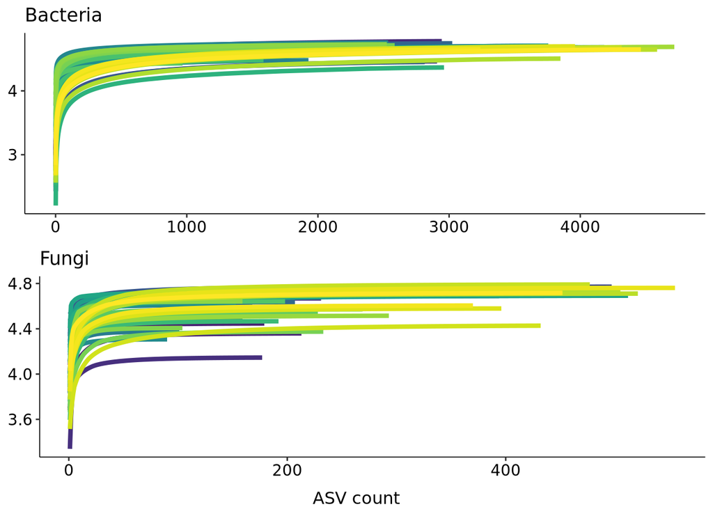

```r
rare_fun <- gfunc(FUN$countData, FUN$colData, "Fungi")

rare_bac <- gfunc(BAC$countData, BAC$colData, "Bacteria")

rarefaction_plots <- grid.arrange(
  rare_bac, rare_fun,
  # left = textGrob(label = expression("log"[10] * " aligned sequences"), rot = 90),
  bottom = "ASV count", nrow = 2
)
```

```r
ggsave(filename = "rarefaction_plots.png", plot = rarefaction_plots, path = FIGURES_DIR)

# Fungi
med <- median(colSums(FUN$countData))
filt <- !colSums(FUN$countData) > med * READ_FILTER
cat("Fungi: ", sum(filt), "sample(s) with <", READ_FILTER * 100, "% of median reads\n\n")
```

```
## Fungi:  0 sample(s) with < 5 % of median reads
```

```r
# Bacteria
med <- median(colSums(BAC$countData))
filt <- !colSums(BAC$countData) > med * READ_FILTER
cat("Bacteria: ", sum(filt), "sample(s) with <", READ_FILTER * 100, "% of median reads\n\n")
```

```
## Bacteria:  0 sample(s) with < 5 % of median reads
```

### 2.3 Filter ASVs by read count

```r
asv_propotions <- function(countData, proportion){
  i <- sum(countData)
  y <- rowSums(countData)
  y <- y[order(y, decreasing = T)]
  asvs <- length(y[(cumsum(y) / i <= proportion)])
  return(asvs)
}

proportions <- c(0.5, 0.9, 0.99, 0.999, 1)

top_asvs <- data.table(
  "proportion" = proportions,
  "Fungi" = lapply(proportions, function(x) asv_propotions(FUN$countData, x)),
  "Bacteria" = lapply(proportions, function(x) asv_propotions(BAC$countData, x))
)

top_asvs |> printTable()
```

| proportion | Fungi | Bacteria |
| --- | --- | --- |
| 0.5 | [41] | [396] |
| 0.9 | [559] | [11019] |
| 0.99 | [3570] | [71217] |
| 0.999 | [6915] | [81640] |
| 1 | [8019] | [84206] |

Keep only ASVs with at least 10 reads in at least 2 samples.

```r
filter_asvs <- function(countData, min_count = 10, min_samples = 2) {
  keep <- rowSums(countData >= min_count) >= min_samples
  names(keep[keep])
}

# Fungi
# keep <- filter_otus(FUN$countData, ASV_FILTER)
keep <- filter_asvs(FUN$countData)
cat(
  "Fungi:\n",
  " - total ASVs:", nrow(FUN$countData), "\n",
  " - removing", nrow(FUN$countData) - length(keep), "ASVs\n",
  " - remaining ASVs:", length(keep), "\n\n"
)
```

```
## Fungi:
##   - total ASVs: 8019
##   - removing 6795 ASVs
##   - remaining ASVs: 1224
```

```r
FUN$taxData <- FUN$taxData[rownames(FUN$taxData) %in% keep,]
FUN$countData <- FUN$countData[rownames(FUN$countData) %in% keep,]

# Bacteria
# keep <-  filter_asvs(BAC$countData, ASV_FILTER)
keep <- filter_asvs(BAC$countData)
cat(
  "Bacteria:\n",
  " - total ASVs:", nrow(BAC$countData), "\n",
  " - removing", nrow(BAC$countData) - length(keep), "ASVs\n",
  " - remaining ASVs:", length(keep), "\n\n"
)
```

```
## Bacteria:
##   - total ASVs: 84206
##   - removing 79847 ASVs
##   - remaining ASVs: 4359
```

```r
BAC$taxData <- BAC$taxData[rownames(BAC$taxData) %in% keep,]
BAC$countData <- BAC$countData[rownames(BAC$countData) %in% keep,]
```

Filtered proportions

```r
proportions <- c(0.5, 0.9, 0.99, 0.999, 1)

top_asvs <- data.table(
  "proportion" = proportions,
  "Fungi" = lapply(proportions, function(x) asv_propotions(FUN$countData, x)),
  "Bacteria" = lapply(proportions, function(x) asv_propotions(BAC$countData, x))
)

top_asvs |> printTable()
```

| proportion | Fungi | Bacteria |
| --- | --- | --- |
| 0.5 | [29] | [247] |
| 0.9 | [262] | [1903] |
| 0.99 | [853] | [3760] |
| 0.999 | [1149] | [4264] |
| 1 | [1224] | [4359] |

## 3 Absolute abundance normalisation

ASV normalisation is performed using qPCR theoretical copy number data. Copy number is calculated per mg of root sample from the qPCR data.

### 3.1 Prepare qPCR abundance data

```r
abundance <- read.csv(here(DATA_DIR, "abundance.csv"))

FUN$abundance <- subset(abundance, Target == "ITS")
BAC$abundance <- subset(abundance, Target == "16S")

rownames(FUN$abundance) <- FUN$abundance$Sample
rownames(BAC$abundance) <- BAC$abundance$Sample

# Add `copy_number` to colData from abundance data `TCN_mg`
FUN$colData$copy_number <- FUN$abundance[rownames(FUN$colData), "TCN_mg"]
BAC$colData$copy_number <- BAC$abundance[rownames(BAC$colData), "TCN_mg"]

FUN$colData$log10_copy_number <- log10(FUN$colData$copy_number + 1)
BAC$colData$log10_copy_number <- log10(BAC$colData$copy_number + 1)
```

## 4 Subset data

For both fungi and bacteria: Subset by each question (experiment and timepoint). Subset by each source (root and soil).

```r
make_subsets <- function(data, group_var, sources = c("root", "soil")) {
  out <- list()
  for (src in sources) {
    sample_idx <- data$colData$source == src & data$colData[[group_var]] == 1
    samples    <- rownames(data$colData)[sample_idx]
    asv_idx    <- rowSums(data$countData[, samples]) > 0 # Drop rows of 0s
    asvs       <- rownames(data$countData)[asv_idx]
    out[[src]] <- list(
      colData   = data$colData[samples, ],
      countData = data$countData[asvs, samples],
      taxData   = data$taxData[asvs, ]
    )
  }
  out
}

EXP <- list(
  FUN = make_subsets(FUN, group_var = "timepoint"),
  BAC = make_subsets(BAC, group_var = "timepoint")
)

TIME <- list(
  FUN = make_subsets(FUN, group_var = "experiment"),
  BAC = make_subsets(BAC, group_var = "experiment")
)
```

## 5 Create DESeq objects

DESeq2 objects are created for each subset of data.

Absolute abundance normalisation using DESeq2 size factors calculated from qPCR-derived copy number.

Size factor values are centred around the mean of the copy number.

```r
create_dds <- function(data, name, source, design = ~ 1) {
  if(identical(colnames(data$countData), rownames(data$colData))) {

    # Create DESeq object
    dds <- DESeqDataSetFromMatrix(
      countData = data$countData,
      colData = data$colData,
      design = design
    )

    # Set size factors based on copy number
    sizeFactors(dds) <- data$colData$copy_number / mean(data$colData$copy_number)
    # Add dds to data list
    data$dds <- dds
    return(data)

    print(paste0(name, ": ", source, " DESeq object created"))
  } else {
    stop(paste0(name, ": ", source, " countData and colData do not match"))
    next
  }
}

# EXP$FUN  <- apply_to_subsets(EXP$FUN, create_dds)
# TIME$FUN <- apply_to_subsets(TIME$FUN, create_dds)

# EXP$BAC  <- apply_to_subsets(EXP$BAC, create_dds)
# TIME$BAC <- apply_to_subsets(TIME$BAC, create_dds)

FUN  <- create_dds(FUN, "FUN", "all")
BAC  <- create_dds(BAC, "BAC", "all")

EXP  <- apply_to_subsets(EXP, create_dds)
TIME <- apply_to_subsets(TIME, create_dds)
```

## 6 Export data objects

```r
saveRDS(FUN, here(OBJECT_DIR, "FUN.rds"))
saveRDS(BAC, here(OBJECT_DIR, "BAC.rds"))
saveRDS(EXP, here(OBJECT_DIR, "EXP.rds"))
saveRDS(TIME, here(OBJECT_DIR, "TIME.rds"))
# saveRDS(EXP$FUN, here(OBJECT_DIR, "EXP$FUN.rds"))
# saveRDS(EXP$BAC, here(OBJECT_DIR, "EXP$BAC.rds"))
# saveRDS(TIME$FUN, here(OBJECT_DIR, "TIME$FUN.rds"))
# saveRDS(TIME$BAC, here(OBJECT_DIR, "TIME$BAC.rds"))
```

## 7 ASV and sample summary

### 7.1 Read and sample summary

```r
#' @title Read summary
#' @description Create a summary of the read counts per sample
#' @param dds DESeq2 object
#' @param norm Logical, whether to normalise the counts
#' @return A data.table with the total, mean, median, max and min reads per sample
#'
read_summary <- function(dds, norm = FALSE) {
  countData <- counts(dds, normalize = norm)
  data.table(
    "Total reads" = sum(countData),
    "Mean reads per sample" = mean(colSums(countData)),
    "Median reads per sample" = median(colSums(countData)),
    "Max reads per sample" = max(colSums(countData)),
    "Min reads per sample" = min(colSums(countData))
  )
}

print_read_summary <- function(data, title) {
  cat("\n", title, "\n")
  data.table(
    "Metric" = c(
      "Total reads", "Mean reads per sample", "Median reads per sample",
      "Max reads per sample", "Min reads per sample"
    ),
    "Root (Raw)" = unlist(read_summary(data$root$dds, FALSE)),
    "Root (Normalized)" = unlist(read_summary(data$root$dds, TRUE)),
    "Soil (Raw)" = unlist(read_summary(data$soil$dds, FALSE)),
    "Soil (Normalized)" = unlist(read_summary(data$soil$dds, TRUE))
  ) #%>%
    # kbl() %>%
    # kable_styling("striped", full_width = F)
}

print_read_summary(EXP$FUN, "Fungi Experiment Read Summary") |> printTable()
```

```
##
##  Fungi Experiment Read Summary
```

| Metric | Root (Raw) | Root (Normalized) | Soil (Raw) | Soil (Normalized) |
| --- | --- | --- | --- | --- |
| Total reads | 553770 | 1167538.914783215 | 899211 | 1410272.920702218 |
| Mean reads per sample | 27688.5 | 58376.94573916074 | 44960.55 | 70513.64603511091 |
| Median reads per sample | 28544 | 50598.51304399495 | 48058 | 54893.23615996225 |
| Max reads per sample | 43565 | 165148.8067557556 | 56554 | 159949.1023980949 |
| Min reads per sample | 9937 | 1580.884399808688 | 21299 | 11011.64393209449 |

```r
print_read_summary(TIME$FUN, "Fungi Timepoint Read Summary") |> printTable()
```

```
##
##  Fungi Timepoint Read Summary
```

| Metric | Root (Raw) | Root (Normalized) | Soil (Raw) | Soil (Normalized) |
| --- | --- | --- | --- | --- |
| Total reads | 601211 | 1231930.739401581 | 978927 | 1786681.147758767 |
| Mean reads per sample | 30060.55 | 61596.53697007905 | 48946.35 | 89334.05738793834 |
| Median reads per sample | 29770.5 | 43680.54180449721 | 48944.5 | 79047.12738040788 |
| Max reads per sample | 43565 | 195610.5356191709 | 56554 | 188514.7672661952 |
| Min reads per sample | 9937 | 8277.259363593146 | 41378 | 15320.97307609972 |

```r
print_read_summary(EXP$BAC, "Bacteria Experiment Read Summary") |> printTable()
```

```
##
##  Bacteria Experiment Read Summary
```

| Metric | Root (Raw) | Root (Normalized) | Soil (Raw) | Soil (Normalized) |
| --- | --- | --- | --- | --- |
| Total reads | 831719 | 1082906.95992713 | 728916 | 967329.454641178 |
| Mean reads per sample | 41585.95 | 54145.34799635648 | 36445.8 | 48366.4727320589 |
| Median reads per sample | 41292.5 | 44430.28723440063 | 37430.5 | 42734.95704577409 |
| Max reads per sample | 53442 | 187048.1829127288 | 48954 | 102297.6118525551 |
| Min reads per sample | 25465 | 16407.3642265588 | 23598 | 13069.70073007331 |

```r
print_read_summary(TIME$BAC, "Bacteria Timepoint Read Summary") |> printTable()
```

```
##
##  Bacteria Timepoint Read Summary
```

| Metric | Root (Raw) | Root (Normalized) | Soil (Raw) | Soil (Normalized) |
| --- | --- | --- | --- | --- |
| Total reads | 832341 | 1124493.577987516 | 745293 | 1050700.426094786 |
| Mean reads per sample | 41617.05 | 56224.67889937581 | 37264.65 | 52535.02130473929 |
| Median reads per sample | 40445 | 37711.15205427141 | 39069 | 44176.12331141658 |
| Max reads per sample | 53442 | 183081.4966060311 | 48954 | 105747.4308637168 |
| Min reads per sample | 27431 | 21622.70055068519 | 18067 | 11708.50961448723 |

### 7.2 ASV summary

```r
#' @title ASV summary
#' @description Create a summary of the read counts per ASV
#' @param dds DESeq2 object
#' @param norm Logical, whether to normalise the counts
#' @return A data.table with the total, mean, median, max and min reads per ASV
#'
asv_summary <- function(dds, norm = FALSE) {
  countData <- counts(dds, normalize = norm)
  data.table(
    "Total ASVs" = nrow(countData),
    "Mean reads per ASV" = round(mean(rowSums(countData)), 1),
    "Median reads per ASV" = median(rowSums(countData)),
    "Max reads per ASV" = max(rowSums(countData)),
    "Min reads per ASV" = min(rowSums(countData))
  )
}

print_asv_summary <- function(data, title) {
  cat("\n", title, "\n")
  data.table(
    "Metric" = c(
      "Total ASVs", "Mean reads per ASV", "Median reads per ASV",
      "Max reads per ASV", "Min reads per ASV"
    ),
    "Root (Raw)" = unlist(asv_summary(data$root$dds, FALSE)),
    "Root (Normalized)" = unlist(asv_summary(data$root$dds, TRUE)),
    "Soil (Raw)" = unlist(asv_summary(data$soil$dds, FALSE)),
    "Soil (Normalized)" = round(unlist(asv_summary(data$soil$dds, TRUE)), 2)
  )
}

print_asv_summary(EXP$FUN, "Fungi Experiment ASV Summary") |> printTable()
```

```
##
##  Fungi Experiment ASV Summary
```

| Metric | Root (Raw) | Root (Normalized) | Soil (Raw) | Soil (Normalized) |
| --- | --- | --- | --- | --- |
| Total ASVs | 845 | 845 | 1114 | 1114 |
| Mean reads per ASV | 655.3 | 1381.7 | 807.2 | 1266 |
| Median reads per ASV | 44 | 95.13043389170643 | 110.5 | 153.05 |
| Max reads per ASV | 28241 | 109873.7844827861 | 63644 | 138504.67 |
| Min reads per ASV | 1 | 0.8366015865144614 | 1 | 1.06 |

```r
print_asv_summary(EXP$BAC, "Bacteria Experiment ASV Summary") |> printTable()
```

```
##
##  Bacteria Experiment ASV Summary
```

| Metric | Root (Raw) | Root (Normalized) | Soil (Raw) | Soil (Normalized) |
| --- | --- | --- | --- | --- |
| Total ASVs | 3707 | 3707 | 3930 | 3930 |
| Mean reads per ASV | 224.4 | 292.1 | 185.5 | 246.1 |
| Median reads per ASV | 49 | 69.45662292649033 | 78 | 94.56 |
| Max reads per ASV | 61996 | 51647.52761422208 | 7176 | 12234.92 |
| Min reads per ASV | 1 | 0.4955326916974707 | 1 | 0.48 |

```r
data.table(
  "Metric" = c(
    "Total ASVs", "Mean reads per ASV", "Median reads per ASV",
    "Max reads per ASV", "Min reads per ASV"
  ),
  "Fungi (Raw)" = unlist(asv_summary(FUN$dds, FALSE)),
  "Fungi (Normalized)" = unlist(asv_summary(FUN$dds, TRUE)),
  "Bacteria (Raw)" = unlist(asv_summary(BAC$dds, FALSE)),
  "Bacteria (Normalized)" = round(unlist(asv_summary(BAC$dds, TRUE)), 2)
) %>%
  kbl() %>%
  kable_styling("striped", full_width = F)
```

| Metric | Fungi (Raw) | Fungi (Normalized) | Bacteria (Raw) | Bacteria (Normalized) |
| --- | --- | --- | --- | --- |
| Total ASVs | 1224.0 | 1.224000e+03 | 4359.0 | 4359.00 |
| Mean reads per ASV | 1835.5 | 1.050620e+04 | 532.8 | 1214.20 |
| Median reads per ASV | 215.5 | 1.298035e+03 | 167.0 | 420.22 |
| Max reads per ASV | 93512.0 | 1.187105e+06 | 88903.0 | 78112.33 |
| Min reads per ASV | 21.0 | 9.113029e+00 | 20.0 | 10.12 |

```r
top_asvs <- function(countData, taxData, n = 10) {
  y <- rowSums(countData)
  y <- y[order(y, decreasing = T)]
  xy <- y / sum(y)
  data.frame(
    counts = y[1:n],
    proportion = xy[1:n],
    rank = taxData[names(y)[1:n],]$rank
  )
}

# top_asvs(FUN$countData, FUN$taxData, n = 10)

top_asvs(counts(FUN$dds, normalize = TRUE), FUN$taxData, n = 10)
```

```
##          counts proportion                     rank
## OTU1  1187105.1 0.09231265  Plectosphaerellaceae(f)
## OTU5   598693.7 0.04655611  Plectosphaerellaceae(f)
## OTU13  516847.8 0.04019155         Pseudeurotium(g)
## OTU8   501718.4 0.03901504  Plectosphaerellaceae(f)
## OTU12  495401.2 0.03852380  Plectosphaerellaceae(f)
## OTU10  397371.7 0.03090075  Plectosphaerellaceae(f)
## OTU20  365763.4 0.02844279  Plectosphaerellaceae(f)
## OTU7   362840.4 0.02821550  Plectosphaerellaceae(f)
## OTU6   357754.7 0.02782002 Penicillium canescens(s)
## OTU4   319120.2 0.02481569  Plectosphaerellaceae(f)
```

```r
top_asvs(counts(BAC$dds, normalize = TRUE), BAC$taxData, n = 10)
```

```
##         counts  proportion                rank
## OTU2  78112.33 0.014758880     Streptomyces(g)
## OTU1  67928.75 0.012834751   Actinobacteria(c)
## OTU14 50744.38 0.009587862 Paenarthrobacter(g)
## OTU3  45529.38 0.008602518     Streptomyces(g)
## OTU17 44983.68 0.008499410   Micrococcaceae(f)
## OTU16 33854.56 0.006396626      Rhizobiales(o)
## OTU27 28686.46 0.005420144   Actinobacteria(p)
## OTU22 28566.85 0.005397545     Arthrobacter(g)
## OTU26 24597.86 0.004647625      Rhizobiales(o)
## OTU40 23532.88 0.004446404         Geomonas(g)
```

## 8 Taxonomy Summary

### 8.1 Taxonomy identifiable

Proportion of ASVs which can be assigned (with the given confidence) at each taxonomic rank.

```r
taxonomy_summary <- function(taxData) {
  tx <- copy(taxData)
  setDT(tx)
  cols <- names(taxData)[9:15]
  tx[, (cols) := lapply(.SD, as.numeric), .SDcols = cols]

  data.table(
    rank = c("kingdom", "phylum", "class", "order", "family", "genus", "species"),
    "0.8" = round(unlist(lapply(cols, function(col) sum(tx[[col]] >= 0.8) / nrow(tx))), 2),
    "0.65" = round(unlist(lapply(cols, function(col) sum(tx[[col]] >= 0.65) / nrow(tx))), 2),
    "0.5" = round(unlist(lapply(cols, function(col) sum(tx[[col]] >= 0.5) / nrow(tx))), 2)
  )
}

# Fungi

taxonomy_summary(FUN$taxData) %>%
  kbl() %>%
  kable_styling("striped", full_width = F)
```

| rank | 0.8 | 0.65 | 0.5 |
| --- | --- | --- | --- |
| kingdom | 1.00 | 1.00 | 1.00 |
| phylum | 0.83 | 0.87 | 0.89 |
| class | 0.74 | 0.77 | 0.79 |
| order | 0.61 | 0.66 | 0.67 |
| family | 0.53 | 0.56 | 0.59 |
| genus | 0.44 | 0.50 | 0.54 |
| species | 0.22 | 0.30 | 0.37 |

```r
# Bacteria

taxonomy_summary(BAC$taxData) %>%
  kbl() %>%
  kable_styling("striped", full_width = F)
```

| rank | 0.8 | 0.65 | 0.5 |
| --- | --- | --- | --- |
| kingdom | 1.00 | 1.00 | 1.00 |
| phylum | 0.90 | 0.93 | 0.95 |
| class | 0.79 | 0.84 | 0.88 |
| order | 0.62 | 0.67 | 0.73 |
| family | 0.50 | 0.54 | 0.58 |
| genus | 0.35 | 0.43 | 0.49 |
| species | 0.00 | 0.00 | 0.00 |

Proportion of reads which can be assigned to each taxonomic rank.

```r
taxonomy_summary_reads <- function(taxData, dds) {
  tx <-taxData[rownames(dds), ]
  nc <- counts(dds, normalize = T)
  ac <- sum(nc)
  cols <- names(tx)[9:15]
  # tx[, (cols) := lapply(.SD, as.factor), .SDcols = cols]

  data.table(
    rank = c("kingdom", "phylum", "class", "order", "family", "genus", "species"),
    "0.8" = round(unlist(lapply(cols, function(col) sum(nc[which(as.numeric(tx[[col]]) >= 0.8),]) / ac)), 2),
    "0.65" = round(unlist(lapply(cols, function(col) sum(nc[which(as.numeric(tx[[col]]) >= 0.65),]) / ac)), 2),
    "0.5" = round(unlist(lapply(cols, function(col) sum(nc[which(as.numeric(tx[[col]]) >= 0.5),]) / ac)), 2)
  )
}

# Fungi

# taxonomy_summary_reads(FUN$taxData, FUN$dds) %>%
#   kbl() %>%
#   kable_styling("striped", full_width = F)

# Bacteria

taxonomy_summary_reads(BAC$taxData, BAC$dds) %>%
  kbl() %>%
  kable_styling("striped", full_width = F)
```

| rank | 0.8 | 0.65 | 0.5 |
| --- | --- | --- | --- |
| kingdom | 1.00 | 1.00 | 1.00 |
| phylum | 0.92 | 0.95 | 0.97 |
| class | 0.80 | 0.86 | 0.90 |
| order | 0.64 | 0.70 | 0.77 |
| family | 0.52 | 0.57 | 0.61 |
| genus | 0.36 | 0.43 | 0.50 |
| species | 0.00 | 0.00 | 0.00 |

### 8.2 Taxonomy plots